# MarkLennyWriteUp

Mark and Lenny

February 21, 2016

# Introduction

In our expierements, we are testing the performance of EC based knapsack solutions compared to a random search solution. We are also testing the effects of various permutation rates withing our EC solutions.

Our score returns the total-value of a given selection of items unless it is overweight. If the selection is overweight, our score returns the capacity minus the total-weight. The overweight score reflects the magnitude to which the selection of items is overweight as a negative number.

We are using a random search as a benchmark to compare the progress of our EC solutions. Random search takes an instance (knapsack problem) and a number of max-tries. Max-tries is the maximum number or solutions the random search will produces within a single run. The random search will generate a random solution to the knapsack and adds the solution and score to a hashtable. When the run is complete, it will return the highest scoring solution among the hashtable.

Our EC solutions manipulate the choice of items, otherwise referred to as a tweak. Each tweak consists of randomly mutating a series of choices. The number of mutations per generation is set by an argument called mutation rate. Our tweak creates a list of random and unique indices of the available choices. This then swaps (0 to 1, 1 to 0) at the indices given by our list. One of the EC solutions has random restarts, the others do not. The random restart will store a winning solution after a given number of mutations and then restart with a random set of choices. In this particular set of expirements, there will be five random restarts in every run. This encourages the algorithm to find the global optima, rather than just the local optima.

# Experimental Setup

We set three permutation rates, two, four, and eight, to our EC solutions. For each mutation rate set up, we tested our EC solution with and without random restarts. In each of these tests, we compared our EC results to that of random searches results. We test all of the these searches on these knapsack problems:

- `knapPI_11_20_1000_4`
- `knapPI_13_20_1000_4`
- `knapPI_16_20_1000_4`
- `knapPI_11_200_1000_4`
- `knapPI_13_200_1000_4`
- `knapPI_16_200_1000_4`

In each test we did 30 runs, each containing 100,000 max-tries.

# Results

## A basic comparison of the searcher (including Mutation Rates)

NOTE: In the following graphs, we refer to our EC Solution, without restarts, as `hill_climber`. We also refer to our EC Solution, with restarts, as `hill_climber_with_restarts`.

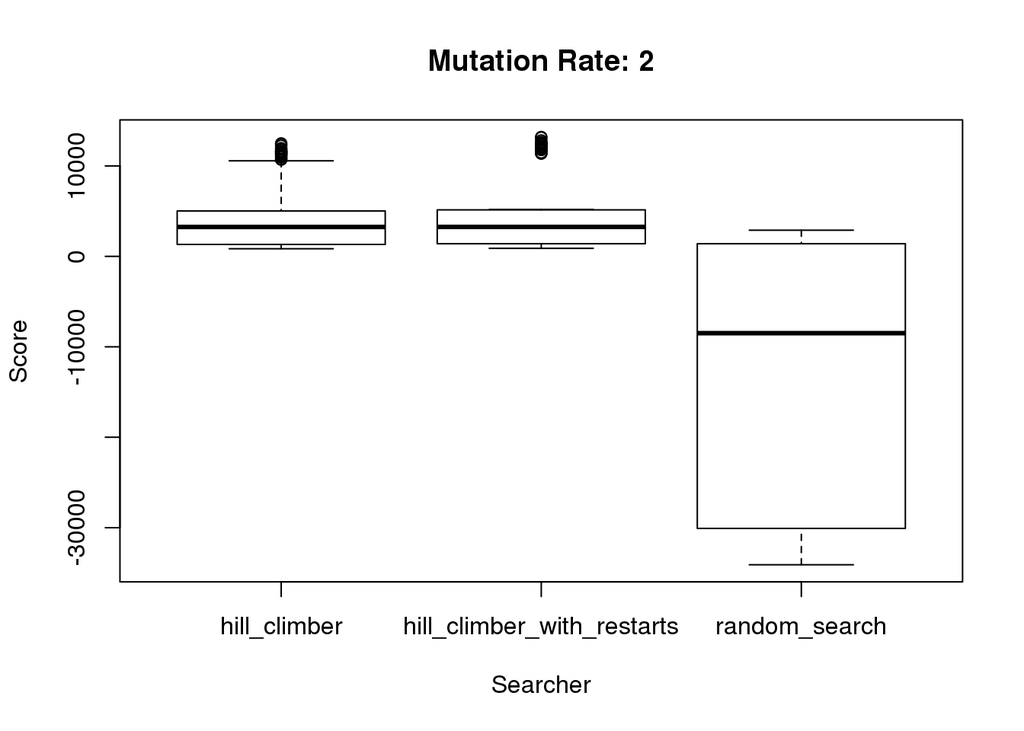

```r
data_50_runs <- read.csv("simpleResultTwo.txt", sep="")

plot(data_50_runs$Score ~ data_50_runs$Search_method,
     xlab="Searcher", ylab="Score", main="Mutation Rate: 2")
```

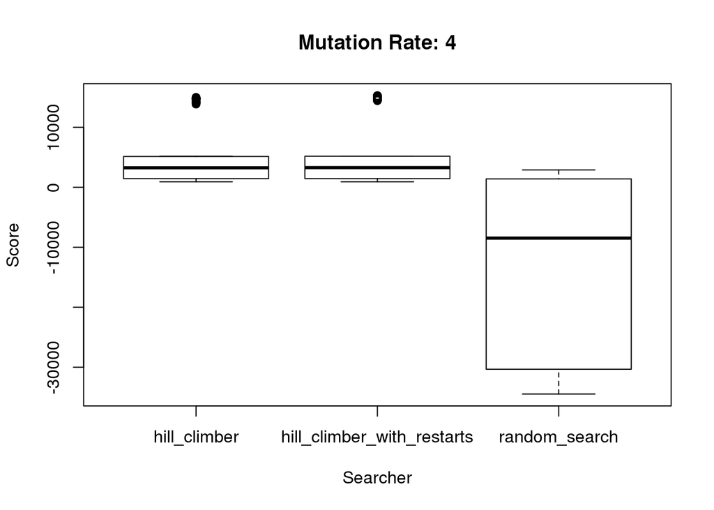

```r
data_50_runs <- read.csv("simpleResultFour.txt", sep="")

plot(data_50_runs$Score ~ data_50_runs$Search_method,
     xlab="Searcher", ylab="Score", main="Mutation Rate: 4")
```

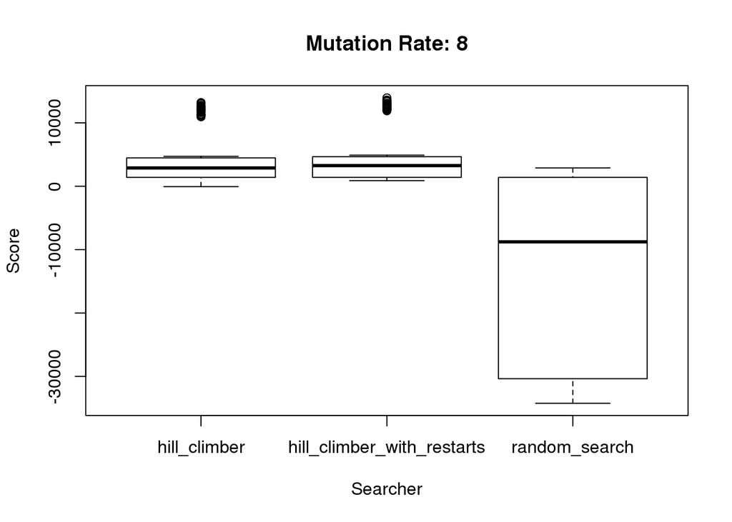

```r
data_50_runs <- read.csv("simpleResultEight.txt", sep="")

plot(data_50_runs$Score ~ data_50_runs$Search_method,
     xlab="Searcher", ylab="Score", main="Mutation Rate: 8")
```

## Scores are floored to zero

Because our scoring mechanism allowed for negative scores, some of the algorithms, particularly, `random_search` had a significant amounts of data below zero. Because these solutions are illegal, we generated a new set of box-plots that only observe legal solutions to the knapsack problem.

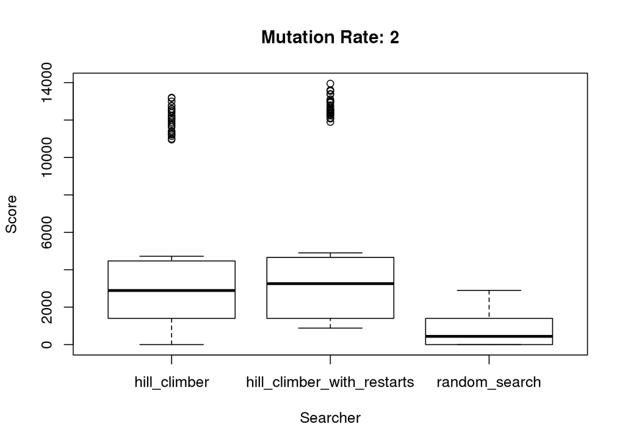

```r
data_50_runs$Non_negative_score = ifelse(data_50_runs$Score<0, 0, data_50_runs$Score)

plot(data_50_runs$Non_negative_score ~ data_50_runs$Search_method,
     xlab="Searcher", ylab="Score", main="Mutation Rate: 2")
```

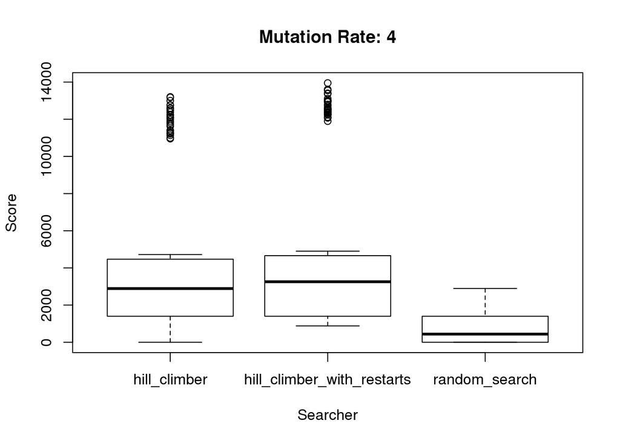

```r
data_50_runs$Non_negative_score = ifelse(data_50_runs$Score<0, 0, data_50_runs$Score)

plot(data_50_runs$Non_negative_score ~ data_50_runs$Search_method,
     xlab="Searcher", ylab="Score", main="Mutation Rate: 4")
```

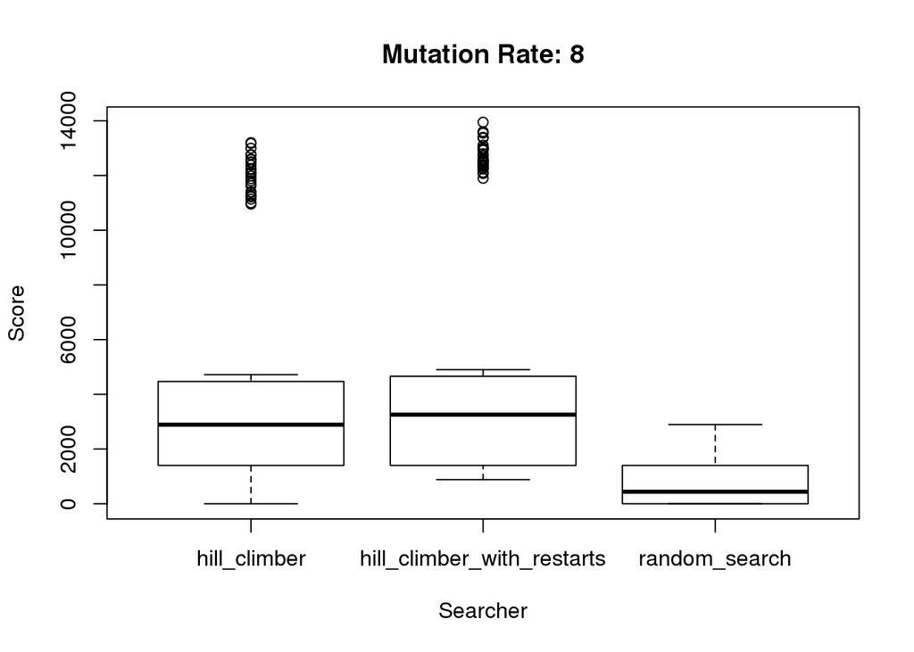

```r
data_50_runs$Non_negative_score = ifelse(data_50_runs$Score<0, 0, data_50_runs$Score)

plot(data_50_runs$Non_negative_score ~ data_50_runs$Search_method,
     xlab="Searcher", ylab="Score", main="Mutation Rate: 8")
```

## How do things change by problem?

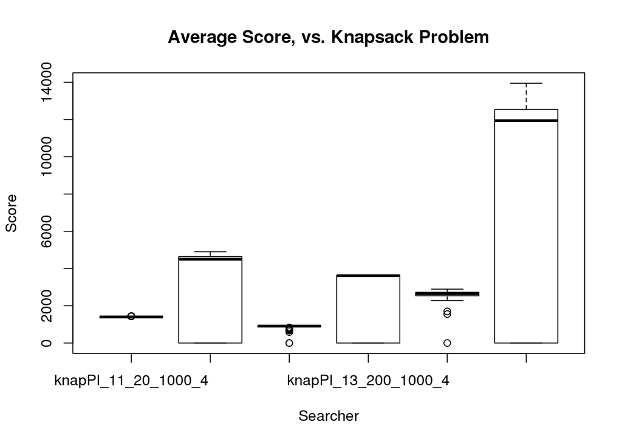

```r
plot(data_50_runs$Non_negative_score ~ data_50_runs$Problem,
     xlab="Searcher", ylab="Score", main="Average Score, vs. Knapsack Problem")
```

When we obseve the result of all the algorithms used (`random_search`, EC without restarts, EC with restarts) for each knapsack problem, we notice that more difficult problems have a high deviation of results. We also observe that the medians on the 200 item knapsack problems are significantly higer. This may be the result of doing enough mutations per run to the point that we reach more high scores than low.

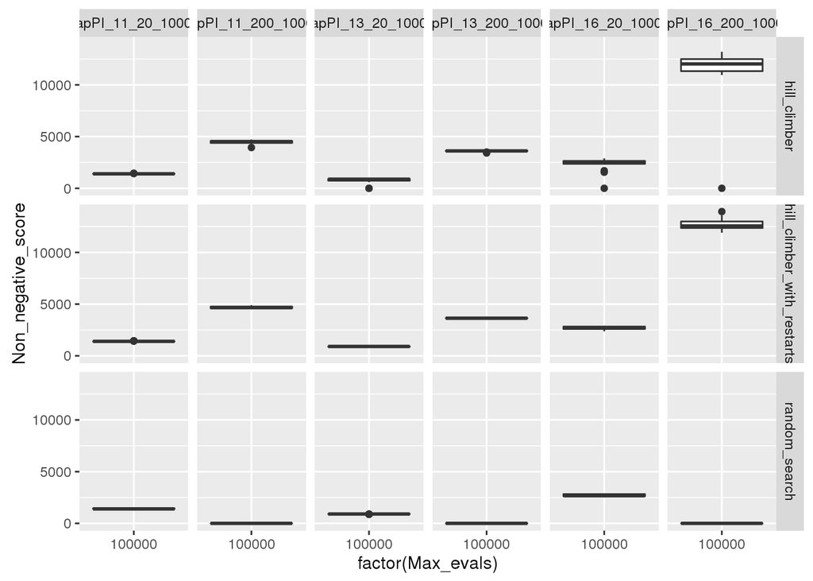

```r
library("ggplot2")

ggplot(data_50_runs,
       aes(x=factor(Max_evals), y=Non_negative_score, group=Max_evals)) +
  geom_boxplot() + facet_grid(Search_method ~ Problem)
```

# Conclusions

Some of our results might have been obscured by the sheer volume of mutations that we have implemented(100,000). This could have negated some of the differences between results of mutation rates and random restarts. Having such a high maximum mutation would allow more primative EC solutions to reach the local or global optimas when in reality it might have taken them substantialy more mutations to get there. For example, `random_search` might have been able to reach a global optima in 70,000 mutations while an EC solution with restarts might have only taken 150 mutations to get to global optima